# Onglet production

## Production d’électricité par filière

Le mix énergétique de l’électricité française est présenté tel qu’en sortie des simulations du Bilan prévisionnel.

Sur ce graphique sont présentées les filières de production (nucléaire, gaz, charbon, fioul, hydraulique, éolien, solaire et autres renouvelables), d’effacements et de flexibilités.

Ces informations sont complétées le solde imports / exports avec l’étranger.

Vous avez la possibilité d’afficher les données sur chacun des 100 premiers tirages simulés pour chacune des coupes du Bilan prévisionnel au pas horaire.

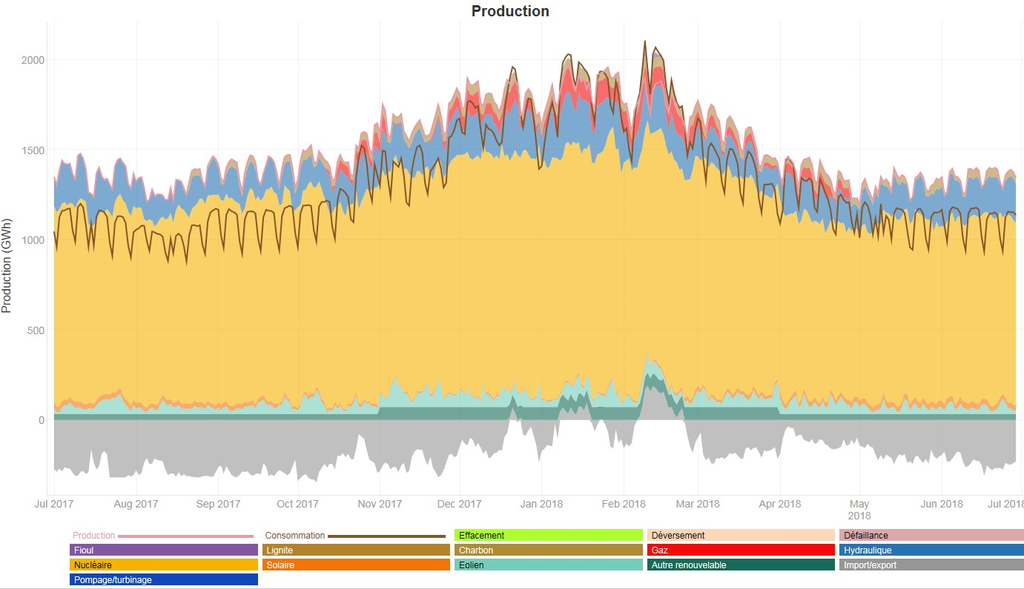

## Personnalisation de la présentation

- Pour chaque filière, vous pouvez basculer en mode “courbe” ou “aire” ou encore la masquer ou la réafficher .
- Avec le bouton “configurer” , vous pouvez également choisir l’agencement des filières de production.

## Précisions sur certaines rubriques et abréviations

### Pompage & STEP Turbinage

Les *STEP* (stations de transfert d’énergie par pompage) sont des installations hydroélectriques qui puisent aux heures creuses de l’eau dans un bassin inférieur afin de remplir une retenue en amont (lac d’altitude). L’eau est ensuite turbinée aux heures pleines pour produire de l’électricité.

- La rubrique **STEP Turbinage** correspond à la puissance produite par l’eau turbinée.
- La rubrique **pompage** représente l’ensemble de la puissance consommée par les STEP.

### Autre renouvelable

La rubrique *Autres* renouvelable représente la production des bioénergies et des hydroliennes.

### Déversement

Le déversement correspond à de l’énergie produite *en trop* par les filières fatales et qui ne trouve pas de débouchés sur les marchés. Les épisodes présentant du déversement sont typiquement des situations avec une consommation faible et de fortes productions renouvelables à l’horizon 2030 ou 2035.

### Tirage

Un tirage correspond à une combinaison d’aléas simulés pour une coupe du Bilan prévisionnel. Une coupe est typiquement simulée sur 1000 combinaisons d’aléas différentes afin de correctement représenter les rares épisodes de défaillances. Les 100 premiers tirages sont mis à la disposition des utilisateurs. Un tirage correspond donc à une réalisation possible à l’horizon étudié.